# E16_Trachea_10X_Dec7_initialSeq+ReSeq_CellRangerv3_mm10.1.2.0_raw

## E16 Trachea sample on Dec7 2018. v2 chemistry. cellRanger version v3.

```r
library(Seurat)
library(dplyr)
```

```r
ZipF<-list.files(path="CombinedReads_raw_v3_mm10.1.2.0",pattern="*.gz",full.names = T,recursive = T)
ZipF
```

```r
library(plyr)
library(R.utils)
ldply(.data=ZipF, .fun=gunzip)  #Unzip CellRanger outputs
```

```r
##### First I manually changed all featurres.tsv to genes.tsv. Otherwise Read10X (Seurat v2) would not recognize...
setwd("./CombinedReads_raw_v3_mm10.1.2.0")
# Load data
file_10Xdir_E16_Dec7_com<-c("E16_Dec7_mut_7","E16_Dec7_mut_8","E16_Dec7_wt_1","E16_Dec7_wt_6")
names(file_10Xdir_E16_Dec7_com)<-c("E16_Dec7_mut_7","E16_Dec7_mut_8","E16_Dec7_wt_1","E16_Dec7_wt_6")
E16_Dec7.data <- Read10X(data.dir = file_10Xdir_E16_Dec7_com)
```

```r
dim(E16_Dec7.data)
```

##### 27998 genes as usual for mm10.1.2.0

##### 2949120 “cells”/barcodes without filtering so far, because I did not use the filtered matrix. I used the raw matrix.

```r
E16_Dec7v3_Trachea <- CreateSeuratObject(raw.data = E16_Dec7.data, min.cells = 1, min.genes = 1000,
    project = "E16_Dec7v3_Trachea")
E16_Dec7v3_Trachea@raw.data@Dim
```

##### 21875 genes detected in at least 1 cell. 20780 “cells” remain.

```r
head(E16_Dec7v3_Trachea@cell.names)
```

```r
E16_Dec7v3_Trachea <- FilterCells(object = E16_Dec7v3_Trachea, subset.names = c("nGene", "nUMI"),
    low.thresholds = c(1000, 5000), high.thresholds = c(Inf, Inf))
E16_Dec7v3_Trachea@data@Dim
```

##### 21875 genes, 19213 cells with nGene>1k, nUMI>5k.

##### extract metadata from cell names:

```r
cell_name<-read.table(text=E16_Dec7v3_Trachea@cell.names,sep="_",colClasses = "character")
age<-cell_name[,1]
names(age)<-E16_Dec7v3_Trachea@cell.names
```

```r
E16_Dec7v3_Trachea<-AddMetaData(object = E16_Dec7v3_Trachea, metadata = age, col.name = "age")
```

```r
sample_date<-cell_name[,2]
names(sample_date)<-E16_Dec7v3_Trachea@cell.names
```

```r
E16_Dec7v3_Trachea<-AddMetaData(object = E16_Dec7v3_Trachea, metadata = sample_date, col.name = "sample_date")
```

```r
genotype<-cell_name[,3]
names(genotype)<-E16_Dec7v3_Trachea@cell.names
```

```r
E16_Dec7v3_Trachea<-AddMetaData(object = E16_Dec7v3_Trachea, metadata = genotype, col.name = "genotype")
```

```r
seq_group<-paste(cell_name[,1],cell_name[,2],cell_name[,3],cell_name[,4],sep="_")
names(seq_group)<-E16_Dec7v3_Trachea@cell.names
```

```r
E16_Dec7v3_Trachea<-AddMetaData(object = E16_Dec7v3_Trachea, metadata = seq_group, col.name = "seq_group")
```

```r
table(E16_Dec7v3_Trachea@meta.data$seq_group)
```

##### add doublet score for each cell as metadata:

```r
load("./CombinedReads_raw_v3_mm10.1.2.0/E16_Dec7_doubletScore.RData")
E16_Dec7v3_Trachea<-AddMetaData(object = E16_Dec7v3_Trachea, metadata = E16_Dec7_doubletScore, col.name = "doublet_score")
sum(is.na(E16_Dec7v3_Trachea@meta.data$doublet_score))
```

```r
median(E16_Dec7v3_Trachea@meta.data$nGene)
```

```r
median(E16_Dec7v3_Trachea@meta.data$nUMI)
```

```r
ribo.genes <- grep(pattern = "^Rp[sl][[:digit:]]", x = rownames(x = E16_Dec7v3_Trachea@data), value = TRUE)
percent.ribo <- Matrix::colSums(E16_Dec7v3_Trachea@raw.data[ribo.genes, ])/Matrix::colSums(E16_Dec7v3_Trachea@raw.data)
E16_Dec7v3_Trachea <- AddMetaData(object = E16_Dec7v3_Trachea, metadata = percent.ribo, col.name = "percent.ribo")
```

```r
mito.genes <- grep(pattern = "^mt-", x = rownames(x = E16_Dec7v3_Trachea@data), value = TRUE)
percent.mito <- Matrix::colSums(E16_Dec7v3_Trachea@raw.data[mito.genes, ])/Matrix::colSums(E16_Dec7v3_Trachea@raw.data)
E16_Dec7v3_Trachea <- AddMetaData(object = E16_Dec7v3_Trachea, metadata = percent.mito, col.name = "percent.mito")
```

```r
VlnPlot(object = E16_Dec7v3_Trachea, features.plot = c("nGene", "nUMI","percent.ribo","percent.mito"), nCol = 1,group.by="seq_group",point.size.use=0.3)
```

[output not shown]

```r
E16_Dec7v3_Trachea <- NormalizeData(object = E16_Dec7v3_Trachea)
```

```r
E16_Dec7v3_Trachea <- ScaleData(object = E16_Dec7v3_Trachea)
```

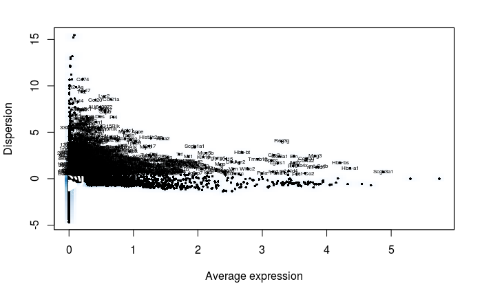

```r
E16_Dec7v3_Trachea <- FindVariableGenes(object = E16_Dec7v3_Trachea, do.plot = TRUE, x.low.cutoff=0.1,x.high.cutoff = Inf, y.cutoff = 0.5)
```

```r
E16_Dec7v3_Trachea <- RunPCA(object = E16_Dec7v3_Trachea, do.print = FALSE)
E16_Dec7v3_Trachea <- ProjectPCA(object = E16_Dec7v3_Trachea, do.print = FALSE)
```

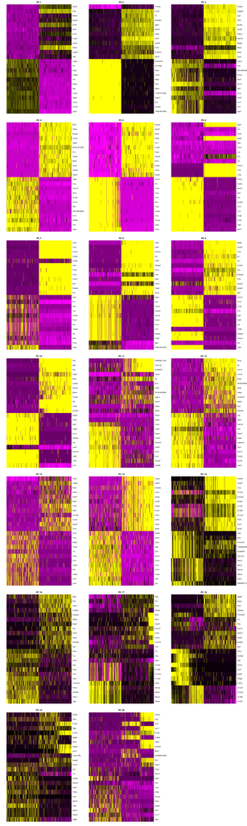

```r
PCHeatmap(object = E16_Dec7v3_Trachea, pc.use = 1:20, cells.use = 500, do.balanced = TRUE, label.columns = FALSE, num.genes = 25)
```

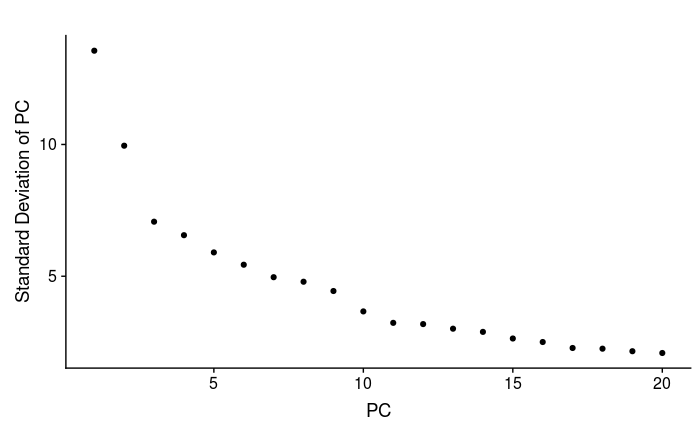

```r
PCElbowPlot(object = E16_Dec7v3_Trachea)
```

```r
n.pcs = 17
res.used <- 0.8
E16_Dec7v3_Trachea <- FindClusters(object = E16_Dec7v3_Trachea, reduction.type = "pca", dims.use = 1:n.pcs,
    resolution = res.used, print.output = 0, save.SNN = TRUE)
```

```r
E16_Dec7v3_Trachea <- RunTSNE(object = E16_Dec7v3_Trachea, dims.use = 1:n.pcs, seed.use = 10, perplexity=30, dim.embed = 2)
```

[figure not shown]

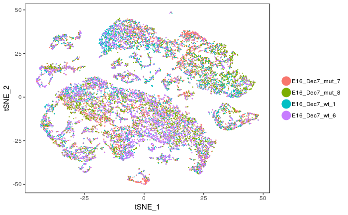

```r
TSNEPlot(object = E16_Dec7v3_Trachea, do.label = F,group.by="seq_group",pt.size = 0.1)
```

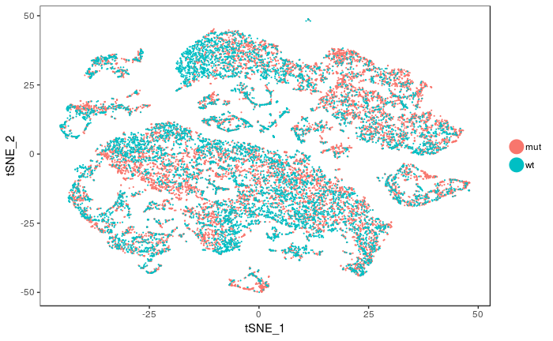

```r
TSNEPlot(object = E16_Dec7v3_Trachea, do.label = F,group.by="genotype",pt.size = 0.1)
```

##### res 1.2:

```r
res.used <- 1.2
E16_Dec7v3_Trachea <- FindClusters(object = E16_Dec7v3_Trachea, reduction.type = "pca", dims.use = 1:n.pcs,
    resolution = res.used, print.output = 0, save.SNN = TRUE)
```

```
Build parameters exactly match those of already computed and stored SNN. To force recalculation, set force.recalc to TRUE.
```

```r
E16_Dec7v3_Trachea <- RunTSNE(object = E16_Dec7v3_Trachea, dims.use = 1:n.pcs, seed.use = 10, perplexity=30, dim.embed = 2)
```

[figure not shown]

```r
load("E16_Dec7v3_Trachea.RData")
```

[output not shown]

##### use resolution=1.2 for the rest of the analysis.

[figure not shown]

[output not shown]

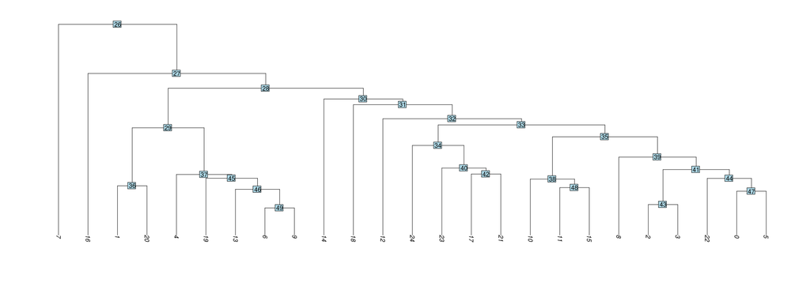

```r
E16_Dec7v3_Trachea=buildClusterTree(E16_Dec7v3_Trachea,do.reorder = F,reorder.numeric = F,pcs.use = 1:17)
```

```r
library(ggalluvial)
```

[figure not shown]

```r
table(E16_Dec7v3_Trachea@meta.data$res.0.8,E16_Dec7v3_Trachea@meta.data$res.1.2)
```

```r
prop.table(table(E16_Dec7v3_Trachea@meta.data$res.1.2,E16_Dec7v3_Trachea@meta.data$seq_group),2)
```

```r
table(E16_Dec7v3_Trachea@meta.data$res.1.2,E16_Dec7v3_Trachea@meta.data$seq_group)
```

[figure not shown]

```r
E16_Dec7_res.1.2.clust.markers <- FindAllMarkers(object = E16_Dec7v3_intron, only.pos = TRUE, min.pct = 0.25, thresh.use = 0.25)
```

```r
E16_Dec_res12_12over23<-FindMarkers(E16_Dec7v3_Trachea,ident.1=c(12),ident.2 = 23,only.pos = TRUE)
E16_Dec_res12_12over23
```

```r
E16_Dec_res12_23over12<-FindMarkers(E16_Dec7v3_Trachea,ident.1=c(23),ident.2 = 12,only.pos = TRUE)
E16_Dec_res12_23over12
```

```r
E16_Dec_res12_23<-FindMarkers(E16_Dec7v3_Trachea,ident.1=c(23),only.pos = TRUE)
E16_Dec_res12_23
```

##### cluster 23 looks like pericyte:

```r
VlnPlot(object = E16_Dec7v3_Trachea, features.plot = c("Acta2","Des","Cd248","Dlk1","Zic1","Notch3","Rgs5","Kcnj8","Abcc9","Cspg4","Pdgfrb","Ano1"), nCol = 1,x.lab.rot = T,point.size.use = 0.3,use.raw=F,group.by="res.1.2")
```

##### Ano1 intron:

```r
VlnPlot(object = E16_Dec7v3_intron, features.plot = c("Ano1","Acta2","Tagln","Notch3"), nCol = 1,x.lab.rot = T,point.size.use = 0.3,use.raw=F,group.by="exon_res.1.2")
```

```r
E16_Dec_res12_16over21<-FindMarkers(E16_Dec7v3_Trachea,ident.1=c(16),ident.2 = 21,only.pos = TRUE)
E16_Dec_res12_16over21
```

```r
E16_Dec_res12_21over16<-FindMarkers(E16_Dec7v3_Trachea,ident.1=c(21),ident.2 = 16,only.pos = TRUE)
E16_Dec_res12_21over16
```

```r
E16_Dec_res12_21<-FindMarkers(E16_Dec7v3_Trachea,ident.1=c(21),only.pos = TRUE)
E16_Dec_res12_21
```

```r
E16_Dec_res12_10over1115<-FindMarkers(E16_Dec7v3_Trachea,ident.1=c(10),ident.2 = c(11,15),only.pos = TRUE)
E16_Dec_res12_10over1115
```

```r
E16_Dec_res12_11over1015<-FindMarkers(E16_Dec7v3_Trachea,ident.1=c(11),ident.2 = c(10,15),only.pos = TRUE)
E16_Dec_res12_11over1015
```

```r
E16_Dec_res12_15over1011<-FindMarkers(E16_Dec7v3_Trachea,ident.1=c(15),ident.2 = c(10,11),only.pos = TRUE)
E16_Dec_res12_15over1011
```

```r
E16_Dec_res12_6over9<-FindMarkers(E16_Dec7v3_Trachea,ident.1=c(6),ident.2 = c(9),only.pos = TRUE)
E16_Dec_res12_6over9
```

```r
E16_Dec_res12_9over6<-FindMarkers(E16_Dec7v3_Trachea,ident.1=c(9),ident.2 = c(6),only.pos = TRUE)
E16_Dec_res12_9over6
```

##### epithelial, neuron/NEC, immune, schwann cell, endothelial, and red blood cells as well as doublets:

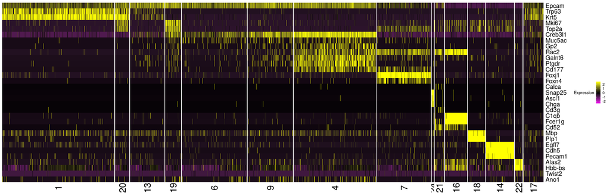

##### cells not included in the previous heatmap:

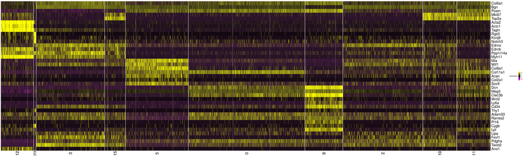

```r
E16_res1.2_c4_wt_mut<-FindMarkers(E16_Dec7v3_Trachea,cells.1<-WhichCells(object=E16_Dec7v3_Trachea,ident=4,cells.use = E16_Dec7v3_Trachea@meta.data$genotype=="wt"),cells.2<-WhichCells(object=E16_Dec7v3_Trachea,ident=4,cells.use = E16_Dec7v3_Trachea@meta.data$genotype=="mut"),only.pos = TRUE)
E16_res1.2_c4_wt_mut
```

```r
E16_res1.2_c4_mut_wt<-FindMarkers(E16_Dec7v3_Trachea,cells.1<-WhichCells(object=E16_Dec7v3_Trachea,ident=4,cells.use = E16_Dec7v3_Trachea@meta.data$genotype=="mut"),cells.2<-WhichCells(object=E16_Dec7v3_Trachea,ident=4,cells.use = E16_Dec7v3_Trachea@meta.data$genotype=="wt"),only.pos = TRUE)
E16_res1.2_c4_mut_wt
```

```r
df_E16_Dec<-FetchData(E16_Dec7v3_Trachea,c("Areg","Il10","Il13","Il18","Il1b","Il33","Il4","Il5","Il6","S100a8","S100a9","Tgfb2","Tnf","Tslp","res.1.2","res.0.8","age","genotype","seq_group","Pigr","Cxcl17","Cxcl14","Ccl25","Ccl28","Cxcl15","Ccl20","Retnlb","Retnla","Itln1","Foxj1","Spdef","Creb3l1","Gp2","Tff2","Scgb1a1","Lcn2","Lgals3","Cftr","Foxi1"))
```

```r
library(ggpubr)

ggplot(df_E16_Dec,aes(genotype,Il33))+facet_grid(.~res.1.2)+geom_dotplot(binaxis="y",aes(color=genotype,fill=genotype),binwidth=0.05,stackdir="center",position=position_dodge(0.8), dotsize=0.2)+stat_compare_means(comparisons = list(c("wt", "mut")),method="wilcox.test",size=4,label="p.adj")+ stat_summary(aes(color=genotype),fun.data=mean_sdl, fun.args = list(mult=1),
                 geom="pointrange",position=position_dodge(0.7))+ theme(axis.text.x = element_text(angle = 45,hjust=1))
```

##### Read loom files (generated by velocyto) using LoomR library, in order to access the intron reads for each cell:

```r
E16_lfile<-connect(filename="E16_Dec_combined_v3.loom",mode="r+")
```

```r
E16_lfile[["matrix"]]
```

```r
E16_lfile[["layers"]]
```

```r
E16_lfile[["row_attrs"]]
```

```r
loom_gene<-E16_lfile[["row_attrs/Gene"]][]
head(loom_gene)
```

```r
write(loom_gene,"loom_geneList.csv",sep=",")
```

##### loom_gene is a lot larger than mm10.1.2.0’s gene list

```r
mm10.1.2.0_geneList<-read.csv(file="../gene_mm10_1_2_0.txt",header=T,sep="\t",stringsAsFactors = F)
```

```r
setdiff(mm10.1.2.0_geneList[,1],loom_gene)
```

```r
loom_diff<-(setdiff(loom_gene,mm10.1.2.0_geneList[,1]))
```

```r
length(loom_diff)
```

##### A lot of loom specific genes are Gm, pseudogenes, etc.

```r
sum(substring(loom_diff,1,2)=="Gm")
```

```r
loom_diff[substring(loom_diff,1,2)!="Gm"]
```

```r
E16_lfile[["col_attrs"]]
```

```r
E16_lfile[["col_attrs/CellID"]][1:5]
```

```r
E16_Dec7v3_intron.data<-as(E16_lfile[["layers/unspliced"]][,],"sparseMatrix")
cell_name<-gsub("x","",E16_lfile[["col_attrs/CellID"]][])
cell_name<-gsub(":","_",cell_name)

dimnames(E16_Dec7v3_intron.data)[[1]]<-cell_name
dimnames(E16_Dec7v3_intron.data)[[2]]<-E16_lfile[["row_attrs/Gene"]][]
E16_Dec7v3_intron.data<-t(E16_Dec7v3_intron.data)
cells.use<-E16_Dec7v3_Trachea@cell.names
filtered_E16_intron<-E16_Dec7v3_intron.data[,cells.use]
```

##### create a seurat object with intron counts only:

```r
E16_Dec7v3_intron <- CreateSeuratObject(raw.data = filtered_E16_intron, min.cells = 0, min.genes = 0,
    project = "E16_Dec7v3_intron")
exon_res0.8<-E16_Dec7v3_Trachea@meta.data$res.0.8
names(exon_res0.8)<-E16_Dec7v3_Trachea@cell.names
E16_Dec7v3_intron<-AddMetaData(object = E16_Dec7v3_intron, metadata = exon_res0.8, col.name = "exon_res.0.8")
exon_res1.2<-E16_Dec7v3_Trachea@meta.data$res.1.2
names(exon_res1.2)<-E16_Dec7v3_Trachea@cell.names
E16_Dec7v3_intron<-AddMetaData(object = E16_Dec7v3_intron, metadata = exon_res1.2, col.name = "exon_res.1.2")
exon_nGene<-E16_Dec7v3_Trachea@meta.data$nGene
names(exon_nGene)<-E16_Dec7v3_Trachea@cell.names
E16_Dec7v3_intron<-AddMetaData(object = E16_Dec7v3_intron, metadata = exon_nGene, col.name = "exon_nGene")
exon_nUMI<-E16_Dec7v3_Trachea@meta.data$nUMI
names(exon_nUMI)<-E16_Dec7v3_Trachea@cell.names
E16_Dec7v3_intron<-AddMetaData(object = E16_Dec7v3_intron, metadata = exon_nUMI, col.name = "exon_nUMI")
seq_group<-E16_Dec7v3_Trachea@meta.data$seq_group
names(seq_group)<-E16_Dec7v3_Trachea@cell.names
E16_Dec7v3_intron<-AddMetaData(object = E16_Dec7v3_intron, metadata = seq_group, col.name = "seq_group")
```

```r
GenePlot(object = E16_Dec7v3_intron, gene1 = "nGene", gene2 = "exon_nGene", use.raw=T,cex.use = 0.3)
```

```r
VlnPlot(object = E16_Dec7v3_intron, features.plot = c("nGene","exon_nGene","nUMI","exon_nUMI"), nCol = 1,x.lab.rot = T,point.size.use = 0.3,use.raw=T,group.by="exon_res.0.8")
```

```r
E16_Dec7v3_intron <- NormalizeData(object = E16_Dec7v3_intron)
```

```r
E16_Dec7v3_intron <- ScaleData(object = E16_Dec7v3_intron)
```

```r
E16_Dec7v3_intron <- SetAllIdent(object = E16_Dec7v3_intron, id = "exon_res.0.8")

DoHeatmap(object = E16_Dec7v3_intron, genes.use = c("Epcam","Trp63","Krt5","Col6a1","Col6a2","Col6a3","Bgn","Postn","Tk1","Mki67","Top2a","Creb3l1","Muc5ac","Gp2","Rac2","Galnt6","Ptgdr","Cd177","Foxj1","Foxn4","Calca","Snap25","Ascl1","Chga","Mbp","Plp1","Egfl7","Cdh5","Pecam1","C1qb","Fcer1g","Cd3g","Acta2","Actc1","Tagln","Alas2","Mia","Wif1","Col8a1","Col11a1","Acan","Col2a1","Sox9","Dcn","Meg3","Clec3b","Adam33","Rarres2","Pi16","Cygb","Pparg","Adrp","Fabp1","Fabp4","Fabp5","Lpl","Lipa","Ednra","Ednrb","Notch3","Ppp1r14a","Myh11","Sfrp2","Mgp","Foxl1","Pdgfra","Twist2","Ano1"),
    slim.col.label = TRUE, group.label.rot = TRUE,use.scaled = T,group.order = c(1,18,14,17,12,2,6,8,20,15,13,11,19,10,5,7,0,9,3,4,16)
  )
```

```r
df_meta_E16_intron<-FetchData(E16_Dec7v3_intron,c("nGene","nUMI","exon_res.0.8","exon_res.1.2"))
```

```r
aggregate(df_meta_E16_intron[, 1:2], list(df_meta_E16_intron$exon_res.1.2), median)
```

```r
E16_Dec7_intron.clust.markers <- FindAllMarkers(object = E16_Dec7v3_intron, only.pos = TRUE, min.pct = 0.25, thresh.use = 0.25)
```

```r
E16_Dec7_intron.clust.markers %>% group_by(cluster) %>% top_n(10, avg_logFC)
```

```r
write.table(E16_Dec7_intron.clust.markers,"marker_res08_E16_Dec7_intron.txt",sep="\t")
```

```r
save(E16_Dec7v3_intron,file="E16_Dec7v3_intron.RData")
load(file="E16_Dec7v3_intron.RData")
```

```r
VlnPlot(object = E16_Dec7v3_intron, features.plot = c("Acta2","Actc1","Tagln","Rgs5","Notch3"), nCol = 1,x.lab.rot = T,point.size.use = 0.3,use.raw=F,group.by="exon_res.1.2")
```

```r
VlnPlot(object = E16_Dec7v3_intron, features.plot = c("Foxn4","Foxj1","Shisa8","Ccno","Hmmr"), nCol = 1,x.lab.rot = T,point.size.use = 0.3,use.raw=F,group.by="exon_res.0.8")
```